# CÀLCULO ACTUARIAL DE SEGUROS GENERALES

FEBRERO 2020

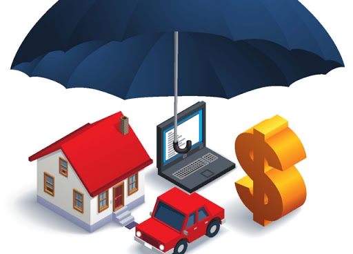

## Agenda

- **Presentación e Introducción**
- **Temario**
- **Forma de Evaluaciòn**

### Presentación e Introducción

`Presentacion Profesor:`

`Profesor:` **Act. Wilibaldo Ortega Sánchez**

`Correo:` **ortega.wilibaldo@gmail.com**

`Repositorio` **https://github.com/Wilibaldo-Ortega**

`Presentacion Alumnos:`

- Nombre
- ¿Donde deseas trabajar? y ¿Por qué?
- Háblame de ti
- ¿Qué te gusta hacer en tu tiempo libre?
- ¿Cuál es tu meta en la vida?
- ¿Cuál es tu mayor debilidad o defecto?
- ¿Cómo describirías tu trabajo ideal?
- ¿Cómo manejas la presión?
- ¿Por qué deberían contratarte?
- ¿Cuáles son tus pretensiones salariales?

`Objetivos:`

**El alumno conocerá y aplicará:**

*-Los principales elementos técnicos involucrados en los seguros de daños.*  
*-Las herramientas estadísticas necesarias para el tratamiento técnico de los seguros de daños.*  
*-Los principios matemáticos necesarios para la formulación de modelos de riesgos.*  
*-Las herramientas matemáticas necesarias para la construcción de diferentes funciones de riesgo utilizadas en el cálculo actuarial.*  
*-Los procedimientos técnicos generales necesarios para el cálculo de las primas y reservas del seguro de la operación de daños.*

*Los modelos generales para el cálculo de primas y reservas técnicas de los diferentes seguros de daños.Todo lo anterior, se realizará a través de la perspectiva de la regulación en México, así como del enfoque en solvencia II, derivado de las necesidades que surgen en el sector asegurador.*

### TEMARIO

`Unidad 1:` **FUNDAMENTOS DE LOS SEGUROS GENERALES**

1.1.- Características esenciales de los seguros de no vida, definiciones y conceptos.

1.2.- Coberturas y Factores de Riesgo fundamentales en los distintos tipos de Seguros Generales

1.2.1.-Responsabilidad Civil y Riesgos Profesionales

1.2.2.- Marítimo y Transporte

1.2.3.- Incendio

1.2.4.- Terremoto y otros riesgos catastróficos

1.2.5.-Agrícola y de animales

1.2.6.- Automóviles

1.2.7.- Crédito

1.2.8.- Diversos

`Unidad 2:` **MATEMÁTICA ACTUARIAL DE NO VIDA, VARIABLES Y CRITERIOS DE DECISIÓN**

2.1.-Variables aleatorias y distribuciones básicas.

2.2.-Número de siniestros.

2.3.-Cuantía individual de los siniestros.

2.3.1.- Número de reclamos (frecuencia)

2.3.2.-Monto de reclamos (severidad)

2.3.3.- Distribuciones logarítmico-normal, de Pareto y mixtura de exponenciales.

2.3.4.-Cola de la distribución.

2.4.- Introducción a la Teoría de los Valores Extremos.

2.4.1.- Distribución de Pareto generalizada.

2.5.- Distribución de la siniestralidad total.

2.6.- Características de la siniestralidad total: transformadas, media, varianza, asimetría.

`Unidad 3:` **REGULACIÒN MEXICANA**

3.1 Registro de productos de Seguros

3.1.1 Nota Técnica

3.1.2 Documentación contractual

3.1.3 Dictamen Jurídico

3.1.4 Dictamen de Congruencia

`Unidad 4:` **CÀLCULO DE PRIMAS EN EL SEGURO DE DAÑOS**

4.1 Comparación entre los seguros de vida y no vida.

4.2 Prima de riesgo o prima pura.

4.2.1 Frecuencia de siniestralidad (exposición al riesgo)

4.2.2 Cuantia del Siniestro

4.3 Regresión multivariada

4.4 Tarificación a posteriori

4.4.1 Teoria de la credibilidad Total y parcial

4.5 Simulación

4.5.1 Los números aleatorios y la simulación

4.5.2 ¿Cuántas simulaciones?, ¿Cuándo se debe simular?

4.5.3 Ejemplo de simulación

4.5.4 Limitaciones del modelo; análisis de sensibilidad

4.6 Prima comercial o de tarifa.

4.7 Elementos condicionados para el cálculo de primas: deducible y coaseguro

`Unidad 5:` **CÀLCULO DE RESERVAS TÈCNICAS**

5.1Demoras en la declaración y liquidación de siniestros

5.2 Triángulo de run-off

5.3 Reservas

5.3.1 Reserva de riesgos en curso

5.3.2 Reserva de siniestros ocurridos pero no reportados

5.4 Métodos para el cálculo de las reservas

5.4.1 Método de Chain Ladder con inflación, sin inflación

5.4.2 Método de la separación

5.4.3 Método de la razón

5.4.4 Bornhuetter Ferguson

5.4.5 BootStrapping

5.5 Método estatutario para la determinación de reservas (Simulaciones)

5.5.1 Margen de Riesgo

5.5.1.1 Desviación

5.5.1.1 Duración

5.5.2 Cálculo de RRC

5.5.2.1 Factor de devengamiento

5.5.2 Cálculo de IBNR

5.5.3 Limitaciones del modelo, análisis de sensibilidad

5.5.4 Importes Recuperables de Reaseguro

5.6 Reserva especial para riesgos catastróficos.

5.6.1 Terremoto y otros riesgos catastróficos

5.6.2 Riesgos Hidrometeorológicos

5.6.3 Agricola y de animales

5.6.4 Crédito y Causión

5.6.5 Crédito a la Vivienda

`Unidad 6:` **REASEGURO**

6.1 Clasificación de reaseguro

6.1.1 Proporcional y no Proporcional

6.1.2 Facultativo y Automático

### Forma de Evaluaciòn

`Evaluación:`

- Examen Parcial 90%
- Tareas 10%
- Si el promedio de calificaciones parciales es mayor o igual a 80% se excentará la materia
- Si el promedio de calificaciones parciales es menor a 80% se presentará evaluación final

`Fecha de Examenes:`

- 1er Parcial - 27 de Marzo
- 2do Parcial - 05 de Junio
- Examen Final - 13 de Junio
- Extraordinario - 25 de Junio
- Titulo de Suficiencia - 04 de Julio

`Nota Importante:`**Se debe cumplir con el 80% de asistencia**